# Assignment1.1

20001247

References: The Hourse data was downloaded from [kaggle] https://www.kaggle.com/c/house-prices-advanced-regression-techniques.

How to write an R Markdown document: http://rmarkdown.rstudio.com

## R for Data Science: https://r4ds.had.co.nz/index.html

The goals of this assignment: 1. Get familier with R studio. 2. Hands on R programming for data analysis.

Total points: 100

## Load libraries (10 points)

If you need to use any R package, add it to the below block. Note that you must install the package before using it.

```r
#install.packages("stringi",type="mac.binary")
#install.packages("Hmisc")
# install.packages("tidyr")
library(GGally)
library(tidyr)
library(Hmisc)
```

## Prepare dataset, complete the following five tasks (50 points)

1. Load data from the given csv file.
2. Report the number of data points in the given csv file.
3. Show the top 5 rows of the loaded dataset.
4. Randomly split the dataset into training and testing, training takes 80%.
5. Take the training data, summarize the data (call the describe function in Hmisc).

```r
#1. read and display the data
mydata = read.csv("housePriceData.csv")
mydata
```

[output not shown]

[output cut: 15382 more lines]

```r
#2. Data statistics
pointCount = nrow(mydata)
pointCount
```

```
## [1] 1460
```

```r
attributeCount = ncol(mydata)
attributeCount
```

```
## [1] 78
```

```r
#3. Show top 5 data points
head(mydata, 5)
```

```
##   Id MSSubClass MSZoning LotFrontage LotArea Street LotShape LandContour
## 1  1         60       RL          65    8450   Pave      Reg         Lvl
## 2  2         20       RL          80    9600   Pave      Reg         Lvl
## 3  3         60       RL          68   11250   Pave      IR1         Lvl
## 4  4         70       RL          60    9550   Pave      IR1         Lvl
## 5  5         60       RL          84   14260   Pave      IR1         Lvl
##   LotConfig LandSlope Neighborhood Condition1 Condition2 BldgType HouseStyle
## 1    Inside       Gtl      CollgCr       Norm       Norm     1Fam     2Story
## 2       FR2       Gtl      Veenker      Feedr       Norm     1Fam     1Story
## 3    Inside       Gtl      CollgCr       Norm       Norm     1Fam     2Story
## 4    Corner       Gtl      Crawfor       Norm       Norm     1Fam     2Story
## 5       FR2       Gtl      NoRidge       Norm       Norm     1Fam     2Story
##   OverallQual OverallCond YearBuilt YearRemodAdd RoofStyle Exterior1st
## 1           7           5      2003         2003     Gable     VinylSd
## 2           6           8      1976         1976     Gable     MetalSd
```

[output cut: 57 more lines]

```r
#4. Randomly split the dataset into 80/20
smp_size <- floor(0.80 * nrow(mydata))

set.seed(123)
train_ind <- sample(seq_len(nrow(mydata)), size = smp_size)

train <- mydata[train_ind, ]
test <- mydata[-train_ind, ]
# train
# test

#5. Summarize training data
require(Hmisc)
describe(train)
```

```
## train
##
##  78  Variables      1168  Observations
## --------------------------------------------------------------------------------
## Id
##        n  missing distinct     Info     Mean      Gmd      .05      .10
##     1168        0     1168        1    738.2    486.3    76.35   153.70
##      .25      .50      .75      .90      .95
##   383.75   735.50  1100.75  1321.30  1384.65
##
## lowest :    1    2    4    5    6, highest: 1456 1457 1458 1459 1460
## --------------------------------------------------------------------------------
## MSSubClass
##        n  missing distinct     Info     Mean      Gmd      .05      .10
##     1168        0       15    0.936    56.47    42.96       20       20
##      .25      .50      .75      .90      .95
##       20       50       70      120      160
##
## lowest :  20  30  40  45  50, highest:  90 120 160 180 190
##
## Value         20    30    40    45    50    60    70    75    80    85    90
## Frequency    440    52     3     8   109   242    49    12    42    14    44
## Proportion 0.377 0.045 0.003 0.007 0.093 0.207 0.042 0.010 0.036 0.012 0.038
##
## Value        120   160   180   190
## Frequency     75    48     7    23
## Proportion 0.064 0.041 0.006 0.020
## --------------------------------------------------------------------------------
## MSZoning
##        n  missing distinct
##     1168        0        5
##
## lowest : C (all) FV      RH      RL      RM
## highest: C (all) FV      RH      RL      RM
##
## Value      C (all)      FV      RH      RL      RM
## Frequency        7      51      14     929     167
## Proportion   0.006   0.044   0.012   0.795   0.143
## --------------------------------------------------------------------------------
## LotFrontage
```

[output cut: 693 more lines]

```
## lowest : Abnorml AdjLand Alloca  Family  Normal
## highest: AdjLand Alloca  Family  Normal  Partial
##
## Value      Abnorml AdjLand  Alloca  Family  Normal Partial
## Frequency       83       4      10      18     948     105
## Proportion   0.071   0.003   0.009   0.015   0.812   0.090
## --------------------------------------------------------------------------------
## SalePrice
##        n  missing distinct     Info     Mean      Gmd      .05      .10
##     1168        0      573        1   180833    80648    88350   107000
##      .25      .50      .75      .90      .95
##   129900   162700   213500   277000   325511
##
## lowest :  39300  40000  52000  52500  55000, highest: 556581 582933 611657 745000 755000
## --------------------------------------------------------------------------------
```

## Variable analysis (20 points)

Given the training data, analyze the relationship between house price, number of bedrooms, number of bathrooms, and house size, using the ggpairs function in GGally package.

Note that you need to first calculate the number of bathrooms for each training point. There are four columns related:

BsmtFullBath: Basement full bathrooms

BsmtHalfBath: Basement half bathrooms

FullBath: Full bathrooms above grade

HalfBath: Half baths above grade.

A half bathroom is calculated as 0.5 full bathroom. For instance, if a house has 3 full bathrooms above grade, 1 full bathroom in basement, 1 half bathroom above grade, this house has 4.5 bathrooms.

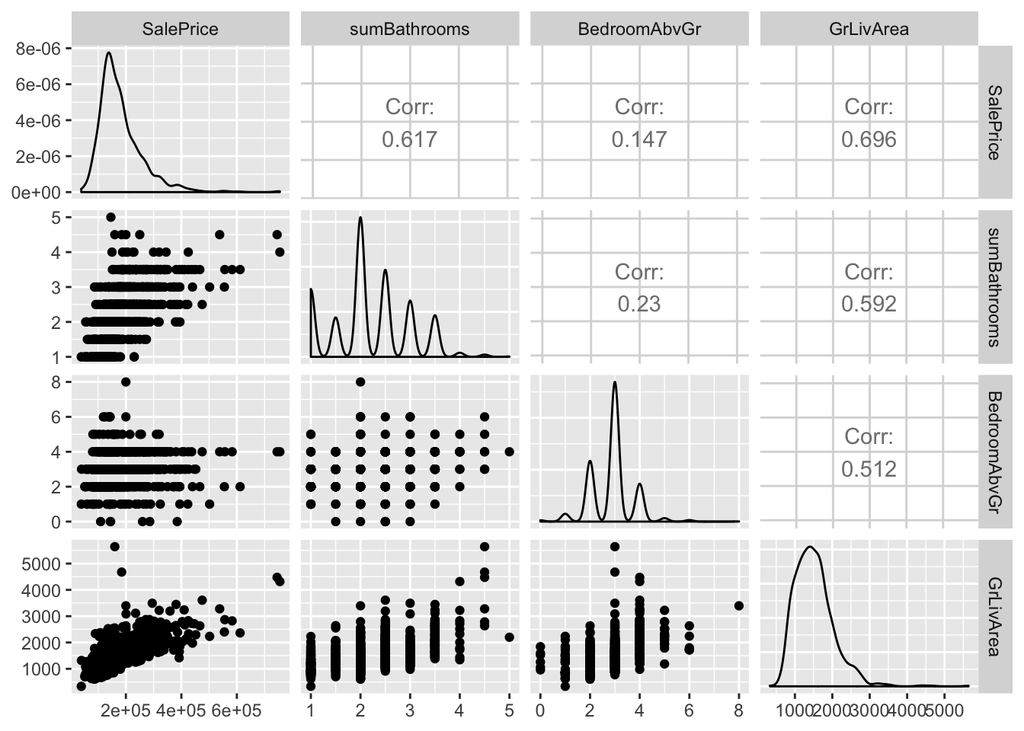

```r
sumBathrooms = train$BsmtFullBath + (0.5*train$BsmtHalfBath) + train$FullBath + (0.5*train$HalfBath)
# sumBathrooms
train <- cbind(train, sumBathrooms)
# train
ggpairs(train, columns = c(78,79,49,44))
```